# Stage 2d: the regional core with China

Stage 2c’s equations on a re-partitioned world — six entities, a euro-area bloc, and the first economy this project had to assemble from scratch

## What this stage is

Stage 2d changes **who** the model is about, and nothing else. Every equation is the one stage 2c settled on — the speed-limit Phillips curve, foreign demand over partner *imports*, the sovereign spread in place of the long-rate level, and the intertemporal-substitution term in consumption. What changes is the partition of the world:

|  | stage 2c | stage 2d |
| --- | --- | --- |
| entities | 11 countries | `de`, `fr`, `it`, `us`, `cn`, `reu` |
| estimation window | 2000Q1–2024Q4 (`T = 98`) | 2005Q1–2024Q4 (`T = 78`) |
| stochastic equations | 68 | 38 |
| identities | 46 | 25 |
| policy rules | `ea_policy_rate`, `us_policy_rate` | those plus `cn_policy_rate` |
| `k` | 76 | **46** |
| `df` | 22 | **32** |

Two of the six entities are not ordinary countries.

- **`reu`** is a *bloc*: the seven modelled euro-area economies other than Germany, France and Italy, aggregated into one pseudo-country with its own equations, its own row and column in the trade-weight matrix, and its own `foreign_demand` identity. Its members contribute no equations of their own.
- **`cn`** is China, the first economy this project has had to assemble rather than fetch. It is also the only one whose block departs from the stage-2c template, and it departs for a data reason, not a modelling preference.

## The two constructed entities

### `reu`: the rest of the euro area

Nominal-GDP weights within the reu bloc (bloc_gdp_weights()).

| member | weight |
| --- | --- |
| AT | 0.0996 |
| BE | 0.1239 |
| ES | 0.3312 |
| GR | 0.0481 |
| IE | 0.1091 |
| NL | 0.2282 |
| PT | 0.0599 |

Every `reu_<concept>` series is built from those weights, with the aggregator chosen by the series’ own attributes: a **level** concept (every volume, every price index) is chained in *growth* space by `chain_weighted_index()`, and a **rate** concept (`unemployment`, `long_rate`) is a weighted average of levels. The distinction is the one that governs `ea_gdp` and `<iso2>_foreign_demand` already — `log(sum_i w_i x_i) != sum_i w_i log(x_i)`, and koma differences everything before it estimates.

**The bloc’s identity weights are its members’ shares averaged, and getting that wrong is easy.** `expenditure_shares()` forms each share as the mean of a *level* ratio, which works for a real country because its series share a currency and a scale. Every bloc series is a base-100 chain index instead, so the ratio is not a share at all — it is the two indices’ relative growth since the base period. Measured on this panel, `mean(reu_exports / reu_gdp)` comes out at **1.337**: `reu` exports grew 2.5x since 2000 while its GDP grew 1.6x, and the ratio reports that rather than an export share. koma has no identity-consistency check, so the wrong weight would have been enforced in silence. `bloc_expenditure_shares()` averages the members’ own shares instead:

reu_gdp identity weights, from the members’ shares. Note reu_exports at 0.598, not 1.337 – Ireland and the Netherlands carry very large trade shares, so the bloc is more open than the euro area as a whole.

| component | weight |
| --- | --- |
| reu_domestic_demand | 0.941 |
| reu_exports | 0.598 |
| reu_imports | -0.548 |

The name is **rest of the euro *area***, not rest of the EU. The bloc covers the seven modelled EA economies, which is what the panel has data for; it is not the EU, and it is not the whole euro area either (the six smallest members were never in `modelled_countries`). Everything genuinely outside the six stage-2d entities still goes to `row_gdp`, so nothing is double-counted — but `reu_gdp` is not a published aggregate and should not be compared against one.

### `cn`: China, and the one thing the public data does not have

So `cn_consumption` and `cn_investment` do not exist. The alternative to inventing them from indicator proxies — retail sales, fixed-asset investment — is to merge them, and that is what `merged_demand_countries` does:

```
cn_domestic_demand ~ cn_gdp + cn_long_rate + cn_domestic_demand.L(1)
cn_exports         ~ cn_foreign_demand + cn_exports.L(1)
cn_imports         ~ cn_domestic_demand + cn_imports.L(1)
cn_prices          ~ eur_usd + oil_price + cn_gdp + cn_prices.L(1)
cn_spread          ~ cn_prices + cn_gdp + cn_spread.L(1)
cn_policy_rate     ~ cn_prices + cn_gdp + cn_policy_rate.L(1)

cn_gdp            == 0.958*cn_domestic_demand + 0.243*cn_exports - 0.201*cn_imports
cn_long_rate      == 1*cn_spread + 1*cn_policy_rate
cn_foreign_demand == (trade-weighted partner imports)
```

The rate term survives the merge unconditionally, because it was investment’s term as well as consumption’s and it is China’s only monetary channel. What is given up is the *split*: there is no separate MPC or accelerator to read off. Net cost is one equation and one column of `k`.

**Sources**, all free and keyless:

| series | source | span (2026-09 vintage) |
| --- | --- | --- |
| `cn_gdp` | WB GEM `NYGDPMKTPSAKN`, real GDP, SA | 1995Q1–2025Q4 |
| `cn_prices` | WB GEM `CPTOTSAXN`, CPI, SA, monthly | 1995M01–2026M02 |
| `cn_exports` | WB GEM `DXGSRMRCHSACD / DXGSRMRCHSAXD` | 2005Q1–2025Q3 |
| `cn_imports` | WB GEM `DMGSRMRCHSACD / DMGSRMRCHSAXD` | 1995Q1–2025Q3 |
| `cn_policy_rate` | OECD `DSD_STES@DF_FINMARK` `IRSTCI` | 1990Q1–2025Q2 |
| `cn_long_rate` | OECD `IRLT` spliced onto `IR3TIB` | see below |

#### Three constructions, each stated because each is one

**Units are reconciled by a constant rescaling.** GDP is constant local currency and the trade volumes are constant US dollars; the three cannot be added. Both volume series are rescaled by a single constant so their window mean equals the mean *nominal* trade share of GDP times mean real GDP, the shares coming from GEM’s own current-dollar series so numerator and denominator share a currency: **0.229** (exports) and **0.188** (imports). A constant multiplicative rescaling changes no growth rate, so koma still differences exactly the published volume index.

**Domestic demand is the accounting residual**, `cn_gdp - cn_exports + cn_imports`, which makes the GDP identity exact in level space (verified to 3.7e-9). Because the trade series are **merchandise only**, the residual absorbs the services balance — for China a persistent services *deficit* — so `cn_domestic_demand` is a little larger than true domestic demand and grows a little differently. Same class of approximation as `<iso2>_gdp`’s statistical discrepancy, and `identity_consistency()` treats it the same way: reported, never flagged.

#### The long rate is the weakest series here

The cn_long_rate splice, measured.

| quantity | value |
| --- | --- |
| mean IRLT - IR3TIB | -0.262 pp |
| sd of that gap | 0.487 pp |
| overlapping quarters | 50 |
| IRLT begins | 2014Q1 |
| quarters spliced in the window | 36 of 80 |

OECD publishes a genuine Chinese 10-year government bond rate, `IRLT`, but only from **2014Q1** — none of the first 36 quarters of the estimation window. Before that, `cn_long_rate` is the three-month interbank rate shifted by the mean gap over the overlap. The shift is additive rather than multiplicative because these are rates in percentage points that pass through koma untransformed, and a ratio splice on a series that can approach zero is not safe.

**The standard deviation of that gap is nearly twice its mean**, so the spliced segment reproduces the *level* of a Chinese long rate but not its independent variation: before 2014 `cn_long_rate` moves exactly like the three-month interbank rate. The consequence is specific — `cn_spread` is a genuine term premium over the second half of the sample and a money-market term spread plus a constant over the first. If that is not acceptable for a given exercise, the clean alternative is `stage2d_config(spread_countries = setdiff(stage2d_countries(), "cn"))`, which lets `cn_domestic_demand` load `cn_policy_rate` directly: `IRSTCI` is complete over the whole window and needs no splice at all.

One further interpolated observation: `IR3TIB` is missing 2006Q1, which `fill_internal_gaps()` fills with a warning naming it.

## Trade weights, and a wart that had to be fixed

Stage-2d trade weights. Rows are reporters, columns partners plus the rest-of-world residual; every row sums to 1.

|  | de | fr | it | us | cn | reu | row |
| --- | --- | --- | --- | --- | --- | --- | --- |
| de | 0.0000 | 0.0648 | 0.0516 | 0.0975 | 0.1041 | 0.2251 | 0.4570 |
| fr | 0.1391 | 0.0000 | 0.0663 | 0.0898 | 0.0800 | 0.2459 | 0.3789 |
| it | 0.1416 | 0.0819 | 0.0000 | 0.0841 | 0.0987 | 0.2002 | 0.3936 |
| us | 0.0440 | 0.0198 | 0.0195 | 0.0000 | 0.1173 | 0.0705 | 0.7289 |
| cn | 0.0345 | 0.0131 | 0.0120 | 0.1150 | 0.0000 | 0.0437 | 0.7817 |
| reu | 0.1699 | 0.0946 | 0.0624 | 0.1144 | 0.1012 | 0.0000 | 0.4575 |

How each row was built.

| reporter | source |
| --- | --- |
| de | direct |
| fr | direct |
| it | direct |
| us | dots |
| cn | dots |
| reu | bloc average |

The euro-area rows come from ECB WTS as everywhere else in this project. The `reu` row is its members’ rows averaged with GDP weights and **intra-bloc trade renormalised away** — 16.8% of the averaged row, which has no external counterparty once the seven members are one entity.

**The `us` and `cn` rows are the fix.** ECB WTS computes weights *for* euro-area reporters only, so stages 1–3 build the US row from the reciprocal of each euro-area country’s own weight on the US, renormalised. Renormalising is where it goes wrong: it forces the modelled partners to account for the reporter’s entire trade. The stage-2b matrix on disk gives the United States a rest-of-world weight of **4.6%** and Ireland a **24.7%** share of US trade — both plainly false, and both already recorded in `CLAUDE.md` as known-unreliable. With only six entities, and China now among them, applying the same construction would have given China a rest-of-world weight of **1.0%** and put 56% of Chinese trade inside the euro area.

Both rows therefore come from observed **IMF Direction of Trade Statistics** instead (`imf_dots_weights()`), where the world total is published and the residual is real: the US at 72.9% rest-of-world and China at 78.2%, with the US–China pair at 11.7% / 11.5%. Two differences from WTS are worth keeping in view, since the two statistics now coexist in one matrix: DOTS is **goods only** where WTS covers manufactured products *and services*, and DOTS is a plain trade share where WTS is a double-weighted effective-exchange-rate weight that also accounts for third-market competition.

### China leaves `row_gdp`

row_gdp_weights(): China is modelled now, so it must come out of the rest-of-world aggregate.

| partner | stages 1-3 | stage 2d |
| --- | --- | --- |
| gb | 0.1242 | 0.1529 |
| ch | 0.0706 | 0.0870 |
| cn | 0.1879 | NA |
| jp | 0.0436 | 0.0537 |
| pl | 0.0663 | 0.0816 |
| se | 0.0352 | 0.0434 |
| other | 0.4722 | 0.5815 |

Passing the stage-2b `row_weights` to stage 2d would not error. It would just load Chinese demand into every partner’s `foreign_demand` identity twice — once directly and once through `row_gdp` — silently.

## Pre-flight and identities

stage2_preflight(): every check passes.

| check | ok | detail |
| --- | --- | --- |
| identity RHS variables all resolve | TRUE | - |
| no variable defined twice | TRUE | - |
| every variable has a panel series | TRUE | 70 variables present |
| no internal NAs in required series | TRUE | - |
| identities declared last | TRUE | 38 stochastic then 25 identities |
| no lagged endogenous name prefixes another | TRUE | - |
| system identified | TRUE | 10/10 seeds pass order + rank |
| k < T (x’x invertible, Wishart df > 0) | TRUE | k = 46, T = 78, df = 32 |
| exact identities hold in the panel | TRUE | 13 checked, worst \|error\| 9.84e-14 |

identity_consistency(). The 13 identities meant to be exact hold to 9.8e-14; the ones reported but never flagged are the GDP and domestic-demand identities, which reconcile only up to the statistical discrepancy.

| identity | space | max_abs_error | exact_expected | ok |
| --- | --- | --- | --- | --- |
| reu_gdp | rate | 5.0027 | FALSE | TRUE |
| reu_domestic_demand | rate | 3.5805 | FALSE | TRUE |
| it_domestic_demand | rate | 2.9630 | FALSE | TRUE |
| de_domestic_demand | rate | 2.3233 | FALSE | TRUE |
| us_domestic_demand | rate | 2.2420 | FALSE | TRUE |
| de_gdp | rate | 1.9607 | FALSE | TRUE |
| it_gdp | rate | 1.9200 | FALSE | TRUE |
| fr_gdp | rate | 1.6589 | FALSE | TRUE |
| cn_gdp | rate | 0.8396 | FALSE | TRUE |
| fr_domestic_demand | rate | 0.5043 | FALSE | TRUE |
| us_gdp | rate | 0.1317 | FALSE | TRUE |
| ea_prices | rate | 0.0000 | TRUE | TRUE |

`reu_gdp`‘s worst error, at 5.0 percentage points of quarterly growth, is the largest in the table and it should be: on top of the statistical discrepancy a single country carries (Germany 2.0, Italy 1.9), the bloc adds a **dispersion** term, because its seven members’ own expenditure shares differ from the average the identity uses. It is the price of the aggregation, it is bounded, and it is of the same order as the country-level slack rather than a different animal.

## Estimation

tune_tau_system(): flagged equations and the worst acceptance rate per round.

| iteration | flagged | max_acceptance |
| --- | --- | --- |
| 0 | 6 | 0.6165 |
| 1 | 9 | 0.6125 |
| 2 | 2 | 0.6065 |
| 3 | 1 | 0.6035 |

All **38 of 38** equations have a Metropolis step — every one of them has a contemporaneous endogenous regressor, which stage 2c’s Phillips curve is what made true. After tuning, acceptance rates run 39.4%–60.4% against the 20–60% band, with 1 equation (reu_exports) marginally over at 60.4%. The doubling rule oscillates around the boundary rather than converging on it; three rounds took the count from 6 to 1 and a fourth would not help. 17 equations carry a `tau` override, all at 2.2.

The eight most persistent own lags. None is explosive.

| equation | term | estimate | ci_high | flagged |
| --- | --- | --- | --- | --- |
| us_policy_rate | us_policy_rate.L(1) | 0.9832 | 1.0526 | FALSE |
| reu_spread | reu_spread.L(1) | 0.9749 | 1.0522 | FALSE |
| ea_policy_rate | ea_policy_rate.L(1) | 0.9722 | 1.0272 | FALSE |
| us_spread | us_spread.L(1) | 0.9598 | 1.0664 | FALSE |
| de_spread | de_spread.L(1) | 0.9431 | 1.0592 | FALSE |
| it_spread | it_spread.L(1) | 0.9356 | 1.0293 | FALSE |
| fr_spread | fr_spread.L(1) | 0.9300 | 1.0488 | FALSE |
| cn_spread | cn_spread.L(1) | 0.8402 | 0.9967 | FALSE |

## Does the structure work?

### Every policy rate reaches every price

contemporaneous_reachability() from each of the three policy rates.

| policy rate | endogenous reached | price variables reached |
| --- | --- | --- |
| ea_policy_rate | 63 / 63 | 7 |
| us_policy_rate | 63 / 63 | 7 |
| cn_policy_rate | 63 / 63 | 7 |

This is the structural claim stage 2c existed to establish, and it survives the re-partition intact. In stage 2b `ea_policy_rate` reached 91 of 103 endogenous variables and **not one price**, so the Taylor rule’s inflation term responded to something nothing it did could influence. Here all three policy rates reach all 63 endogenous variables and all seven price variables. Adding a third rule does not weaken it: China’s rule closes its own loop through `cn_prices -> cn_policy_rate -> cn_long_rate -> cn_domestic_demand -> cn_gdp -> cn_prices`, and reaches the euro area and the US through the trade identities.

Reachability is exact and verifiable. It is **not** a claim that the response has the right sign or size — stage 2c’s own lesson was that closing the loop structurally did not make the monetary shock work, and only the seed placebo showed it. A spillover battery on this system is the obvious next step and is not in this report.

### Sign checks

sign_checks() across the six entities: 26 of 30 pass.

|  | fail | pass |
| --- | --- | --- |
| absorption_positive | 0 | 1 |
| consumption_rate_channel_negative | 1 | 4 |
| demand_rate_channel_negative | 0 | 1 |
| import_elasticity_positive | 0 | 6 |
| mpc_in_0_1 | 0 | 5 |
| phillips_curve_positive | 2 | 4 |
| spread_loads_on_prices_positive | 1 | 5 |

The failures.

| iso2 | check | equation | term | estimate |
| --- | --- | --- | --- | --- |
| de | phillips_curve_positive | de_prices | de_gdp | -0.0773 |
| fr | spread_loads_on_prices_positive | fr_spread | fr_prices | -0.0381 |
| it | phillips_curve_positive | it_prices | it_gdp | -0.0029 |
| it | consumption_rate_channel_negative | it_consumption | it_long_rate | 0.0261 |

26 of 30 pass. The two Phillips-curve failures are small and both straddle zero — Italy’s at -0.00294 is indistinguishable from nothing at all. `spread_loads_on_prices_positive` was already flagged in stage 2c as the weakest of the four a priori, since a flight-to-quality episode compresses spreads while inflation rises. None of the four is in a China or `reu` equation, which is the useful negative result: the two constructed entities are not where the specification strains.

### The merged China equation, judged against the right benchmark

Domestic-demand elasticity to GDP: implied from the split for the five entities that have it, estimated directly for China.

| iso2 | consumption | investment | elasticity |
| --- | --- | --- | --- |
| de | 0.159 | 1.922 | 0.633 |
| fr | 0.960 | 0.954 | 0.959 |
| it | 0.725 | 1.761 | 0.984 |
| us | 0.612 | 3.869 | 1.264 |
| reu | 0.673 | -0.170 | 0.428 |
| cn | NA | NA | 1.101 |

**The first bound put on this rule was wrong, and the data said so.** The obvious rule for a merged demand equation is the MPC’s — a coefficient in `(0, 1)` — and China’s 1.101 fails it. But an MPC below one is a claim about *consumption*; total domestic absorption also contains investment, which is far more cyclical than output. Computing the implied elasticity for the five entities that do have the split gives 0.43–1.26, with the **United States at 1.264** — so a `(0, 1)` bound would have reported the US as a failure too. The rule is `> 0`, and China’s estimate sits inside the range the other five span. Reporting a correct coefficient as a failure because of a rule invented alongside it is exactly the trap this project has hit before.

The rate term in that equation is -0.0188 with a 90% interval of [-0.412, 0.272] — correctly signed and firmly indistinguishable from zero. Given that 36 of the 80 quarters of `cn_long_rate` are spliced, that is the expected result rather than a surprise, and it is the strongest argument for trying the `spread_countries`-without-China variant.

### What the bloc costs: `reu_investment`

The investment equations. reu is the most volatile series and the worst-fitting equation, despite being an average of seven economies.

| entity | sd of growth | accelerator (on gdp) | in-sample RMSE |
| --- | --- | --- | --- |
| de | 2.16 | 1.922 | 1.22 |
| fr | 2.74 | 0.954 | 0.78 |
| it | 4.08 | 1.761 | 1.49 |
| us | 3.98 | 3.869 | 1.91 |
| reu | 6.46 | -0.170 | 4.34 |

**Averaging seven economies should reduce volatility. Here it raises it**, and that is the tell. `reu_investment` has a quarterly growth standard deviation of 6.46, against 2.16–4.08 for the four real countries. The cause is the one this project has already documented for Ireland: `ie_investment` has a growth sd of **43.0** on this window, against 2.2 for Austria and 3.0 for Portugal, and Ireland carries a 10.9% weight in the bloc — so Ireland alone contributes more to `reu_investment`’s variance than every other member combined. The Netherlands (sd 14.0) adds most of the rest.

The consequence is that **this one equation is not identified**. Its accelerator is -0.17 with a 90% interval of [-2.77, 2.14] — wrong-signed, but so wide that the sign carries no information — and its own lag has gone to -0.567, i.e. the equation has collapsed into mean-reversion around noise rather than an accelerator. Its in-sample RMSE is 4.34 against 0.78–1.91 for the others.

There is deliberately no sign rule for the investment accelerator in `base_sign_rules()`, so nothing flagged this — it surfaced only from computing the implied demand elasticity above, which came out lowest for `reu` at 0.428. That is the familiar lesson in a new place: **a neighbouring coefficient moving is the first symptom**, and the check that would have caught it directly does not exist.

Stages 2b and 2c work around Irish measured GDP with `ireland_proxy`, which swaps the *foreign-demand basis* for a better-behaved Irish series. That switch is unavailable here, because the distortion is now inside an **estimated** equation rather than in an identity’s components. Two things would actually help, neither of them attempted in this report: weighting the bloc by something less Ireland-heavy than nominal GDP, or excluding Ireland from `reu` entirely and carrying it as its own entity or in `row_gdp`. Until then, read `reu_investment` as unidentified, and treat `reu_domestic_demand` — which inherits it through the identity — as correspondingly soft.

## What this stage is and is not for

**Use it for** anything where the euro area’s three largest economies, the US and China need to interact inside one estimated system, and where `df = 32` matters more than country detail: cross-bloc spillovers, a China demand or policy shock, the transmission of a US rate move into euro-area activity.

**The three things to watch** are stated above rather than buried: `cn_long_rate` is spliced over 45% of the window, `reu_investment` is not identified because Ireland dominates the bloc’s investment variance, and `reu`’s identities carry a dispersion term on top of the usual statistical discrepancy. Neither is hidden from the diagnostics — the splice is measured in `cn_long_rate_series()` and the dispersion shows up in `identity_consistency()` as the largest error in the table.

## Eight-quarter forecast

8 quarters from **2025Q1** to **2026Q4**, 1000 posterior draws. Actuals exist for the first 5 quarters; the rest is genuinely ahead of the data.

Every fan below is the **filtered** predictive interval: koma constrains no draw to be stationary, so a draw whose quarterly growth exceeds 100% in absolute value is dropped before the quantiles are taken, exactly as `score_forecast()` does when it scores a backtest. The solid band is the 25th-75th percentile of what survives, the faint band the 10th-90th, the dark line their median, and the grey line the realised path where one exists. Across the variables shown, **1.6%** of draws are discarded as explosive at horizon 1, rising to **34.1%** at horizon 8 (worst: `it_gdp` at 43.6%). A variable whose discarded share climbs steeply is one whose fan **understates** the model’s true uncertainty, so read the tail of a wide fan as an ordering rather than a number.

**The panels are clipped, and that is worth saying plainly.** Eight quarters out, the 10-90 interval on *quarterly* growth spans tens of percentage points in every stage of this project – an honest number, and one that makes the median invisible if the axis is scaled to contain it. Each panel is therefore scaled to its inner band, and the outer band runs to the panel edge rather than being drawn in full. Nothing is concealed: the table at the end of this section reports the untruncated bounds.

Every level path is anchored on an **observed** value (largest anchor discrepancy 0.00%, on `fr_imports`), so the level and rate charts are both directly comparable to the actuals.

### GDP

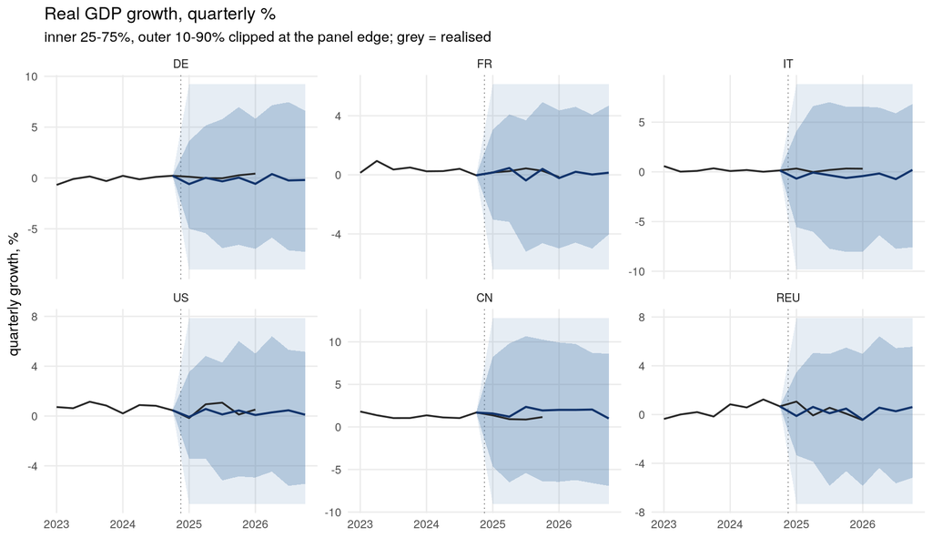

Median GDP growth forecast by quarter, percent.

| quarter | DE | FR | IT | US | CN | REU |
| --- | --- | --- | --- | --- | --- | --- |
| 2025Q1 | -0.60 | 0.16 | -0.68 | -0.07 | 1.58 | -0.12 |
| 2025Q2 | 0.01 | 0.46 | -0.07 | 0.56 | 1.21 | 0.62 |
| 2025Q3 | -0.33 | -0.38 | -0.34 | 0.13 | 2.35 | 0.11 |
| 2025Q4 | 0.04 | 0.40 | -0.62 | 0.45 | 1.94 | 0.48 |
| 2026Q1 | -0.58 | -0.22 | -0.42 | 0.08 | 2.01 | -0.42 |
| 2026Q2 | 0.38 | 0.21 | -0.17 | 0.29 | 2.00 | 0.56 |
| 2026Q3 | -0.24 | 0.02 | -0.73 | 0.46 | 2.05 | 0.27 |
| 2026Q4 | -0.20 | 0.15 | 0.20 | 0.11 | 1.00 | 0.61 |

### Prices

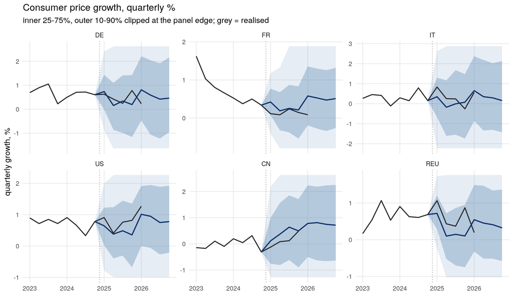

Median price growth forecast by quarter, percent.

| quarter | DE | FR | IT | US | CN | REU |
| --- | --- | --- | --- | --- | --- | --- |
| 2025Q1 | 0.74 | 0.42 | 0.35 | 0.64 | 0.12 | 0.72 |
| 2025Q2 | 0.16 | 0.19 | -0.18 | 0.38 | 0.37 | 0.10 |
| 2025Q3 | 0.34 | 0.25 | -0.01 | 0.49 | 0.64 | 0.15 |
| 2025Q4 | 0.19 | 0.21 | 0.07 | 0.36 | 0.50 | 0.10 |
| 2026Q1 | 0.81 | 0.58 | 0.65 | 1.01 | 0.78 | 0.54 |
| 2026Q2 | 0.59 | 0.53 | 0.35 | 0.95 | 0.81 | 0.45 |
| 2026Q3 | 0.42 | 0.47 | 0.29 | 0.75 | 0.75 | 0.41 |
| 2026Q4 | 0.46 | 0.51 | 0.15 | 0.78 | 0.71 | 0.32 |

### Policy rates

A `method = "none"` series passes through koma untouched, so for a policy rate the forecast **is** the level – there is no rate-versus-level distinction to make, and no anchoring question either.

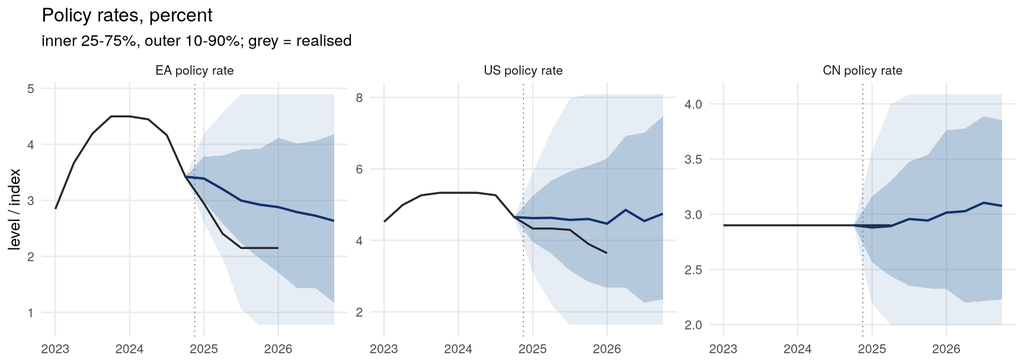

Median policy-rate path, percent.

| quarter | ea_policy_rate | us_policy_rate | cn_policy_rate |
| --- | --- | --- | --- |
| 2025Q1 | 3.39 | 4.62 | 2.88 |
| 2025Q2 | 3.20 | 4.63 | 2.89 |
| 2025Q3 | 3.00 | 4.57 | 2.96 |
| 2025Q4 | 2.92 | 4.60 | 2.94 |
| 2026Q1 | 2.88 | 4.46 | 3.01 |
| 2026Q2 | 2.79 | 4.85 | 3.03 |
| 2026Q3 | 2.73 | 4.54 | 3.10 |
| 2026Q4 | 2.63 | 4.74 | 3.08 |

### What was discarded, and what the exogenous path assumes

Share of posterior draws discarded as explosive, by variable.

| variable | explosive share, h1 | h8 | max |
| --- | --- | --- | --- |
| it_gdp | 0.046 | 0.436 | 0.436 |
| cn_gdp | 0.036 | 0.409 | 0.409 |
| de_gdp | 0.027 | 0.402 | 0.402 |
| fr_gdp | 0.019 | 0.388 | 0.388 |
| reu_gdp | 0.016 | 0.388 | 0.388 |
| us_gdp | 0.020 | 0.378 | 0.378 |
| it_prices | 0.008 | 0.315 | 0.315 |
| de_prices | 0.004 | 0.292 | 0.292 |
| cn_prices | 0.005 | 0.292 | 0.292 |
| us_prices | 0.004 | 0.270 | 0.270 |
| reu_prices | 0.002 | 0.268 | 0.268 |
| fr_prices | 0.000 | 0.258 | 0.258 |

The untruncated predictive band at horizon 8 – quarterly growth, percent. This is what the charts clip.

| variable | median | inner_low | inner_high | outer_low | outer_high | outer_width |
| --- | --- | --- | --- | --- | --- | --- |
| de_gdp | -0.2 | -7.3 | 6.6 | -24.4 | 26.2 | 50.6 |
| fr_gdp | 0.1 | -4.0 | 4.7 | -21.5 | 18.3 | 39.8 |
| it_gdp | 0.2 | -7.6 | 6.8 | -23.3 | 27.3 | 50.6 |
| us_gdp | 0.1 | -5.4 | 5.2 | -19.1 | 20.2 | 39.3 |
| cn_gdp | 1.0 | -6.9 | 8.6 | -17.8 | 23.4 | 41.2 |
| reu_gdp | 0.6 | -5.2 | 5.6 | -17.9 | 24.2 | 42.1 |
| de_prices | 0.5 | -1.0 | 2.2 | -8.4 | 7.3 | 15.7 |
| fr_prices | 0.5 | -0.3 | 1.3 | -3.5 | 4.1 | 7.6 |
| it_prices | 0.2 | -1.4 | 2.1 | -8.0 | 7.4 | 15.4 |
| us_prices | 0.8 | -0.2 | 1.9 | -3.7 | 7.3 | 11.0 |
| cn_prices | 0.7 | -0.6 | 2.2 | -5.2 | 7.0 | 12.2 |
| reu_prices | 0.3 | -0.6 | 1.4 | -2.8 | 4.5 | 7.3 |

A forecast this long needs the **exogenous** series to reach the end of the horizon, and they do not: every one of them stops at the fit’s own native forecast end. `extend_forecast_horizon()` carries each one forward on its trailing four-quarter average growth – a momentum continuation, not a view on oil markets or world trade – and koma would otherwise have silently returned a shorter horizon than the one requested.

How each exogenous series was carried past the fit’s native forecast end.

| variable | method | periods_added |
| --- | --- | --- |
| covid_2020q1 | zero (dummy) | 3 |
| covid_2020q2 | zero (dummy) | 3 |
| covid_2020q3 | zero (dummy) | 3 |
| covid_2021q2 | zero (dummy) | 3 |
| eur_usd | trailing-4Q avg growth (2.67%/q) | 3 |
| oil_price | trailing-4Q avg growth (1.41%/q) | 3 |
| row_gdp | trailing-4Q avg growth (0.44%/q) | 3 |